# Protein_aggregation_vs_subcellular_location

# Initialization

## Install all the needed libraries.

```r
#install.packages("UniprotR")
#install.packages("BiocManager")
#BiocManager::install("Biostrings")
#BiocManager::install("GenomicAlignments")
#install.packages("sjmisc")
#install.packages("hash")
#install.packages("dplyr")
#install.packages("Peptides")
```

## Load the needed libraries.

```r
library(UniprotR)
library(sjmisc) # Used for str_contains
library(hash) # Used to make a disctionary
library(dplyr) # Used for aggregate (get avg tango score of protein)
library(Peptides) # Used for charge (get the charge of a peptide sequence) ETC
library(ggplot2)
library(dplyr)
library(ggrepel)
library(tidyverse)
```

## Define the working directory.

```r
directory = dirname(rstudioapi::getSourceEditorContext()$path) # Place the data in a Data folder on the path of this file
setwd(directory)
```

## Load the data.

```r
source("load_data.R")
return_value = read_data() # See load_data.R
data = return_value$data
hashed_proteins = return_value$hashed_proteins
rm(return_value) # To get rid of the extra memory usage
```

# TANGO scores

```r
source("tango_scores.R")
```

```
Errore: C stack usage  7969344 is too close to the limit
```

## Average tango score distribution in all proteins

```r
significance_tango_scores_complete_proteins_joined_secreted()
```

```
Avvertimento in ks.test(x, y): cannot compute correct p-values with ties
```

```
[1] "The observed difference is statistically significant"
```

## Average tango score distribution in proteins with an APR region

```r
significance_tango_scores_APR_proteins_joined_secreted()
```

```
Avvertimento in ks.test(x, y): cannot compute correct p-values with ties
```

```
[1] "The observed difference is statistically significant"
```

Is this significantly different from the analysis without proteins that don’t have an APR region?

```r
source("statistical_analysis.R")

# F_test(unlist(tango_scores_complete_protein, recursive = TRUE, use.names = TRUE), unlist(tango_scores_APR_protein, recursive = TRUE, use.names = TRUE))
# TODO
```

## Distribution of maximal tango scores

```r
significance_tango_scores_max_joined_secreted()
```

```
Avvertimento in ks.test(x, y): cannot compute correct p-values with ties
```

```
[1] "The observed difference is not statistically significant"
```

```r
significance_tango_scores_complete_proteins_joined_secreted()
```

```
Avvertimento in ks.test(x, y): cannot compute correct p-values with ties
```

```
[1] "The observed difference is statistically significant"
```

# Peptide charges

```r
source("charges.R")
classify_subsets()
```

```r
# TODO: make plots showing the differences between APR, GK and FR based on charges
# TODO: see if differences when split into subcellular locations

# protein_sequences_APR_peptides = get_charge(APR_peptides)
# protein_sequences_GK_peptides = get_charge(GK_peptides)
# protein_sequences_FR_peptides = get_charge(FR_peptides)
```

# Pie Plot for the residues

Lysine (Lys) –> K  
Arginine (Arg) –> R  
Aspartic acid (Asp) –> D  
Glutamic acid (Glu) –> E

```r
source("gatekeeper.R")
```

## Only for the GK regions

```r
GK_analysis = analyse_gate_keeper_regions()
```

PERCENTAGE OF ALL RESIDUES FOR ALL OF THE GK REGIONS IN ALL PROTEINS

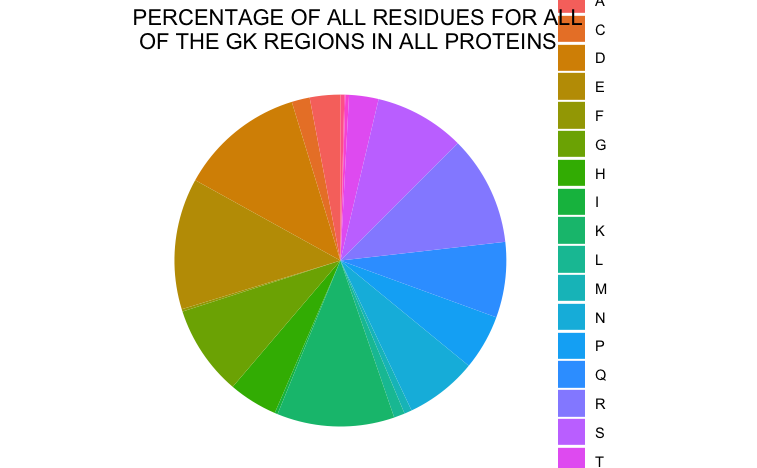

```r
pie_plot_percentage_of_all_residues(GK_analysis$cts_gk, "GK REGIONS")
```

PERCENTAGE OF ALL RESIDUES FOR ALL OF THE GK + FL REGIONS IN ALL PROTEINS

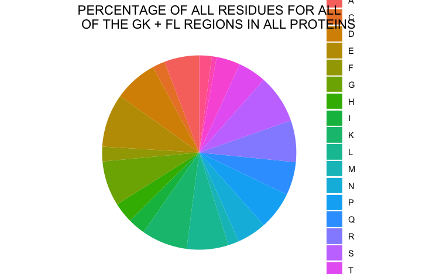

```r
pie_plot_percentage_of_all_residues(GK_analysis$cts_gk_fl, "GK + FL REGIONS")
```

PERCENTAGE OF ALL GROUPS OF RESIDUES FOR ALL THE GK REGIONS IN ALL PROTEINS

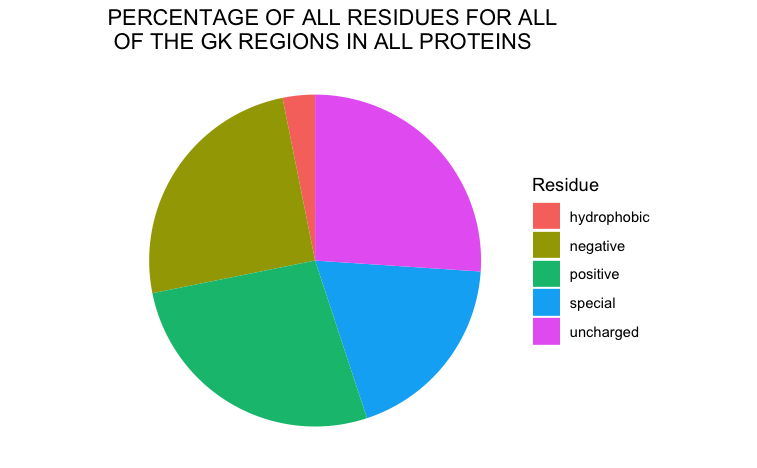

```r
pie_plot_percentage_of_all_residues(GK_analysis$cts_gk_groups, "GK REGIONS")
```

PERCENTAGE OF ALL GROUPS OF RESIDUES FOR ALL THE GK + FL REGIONS IN ALL PROTEINS

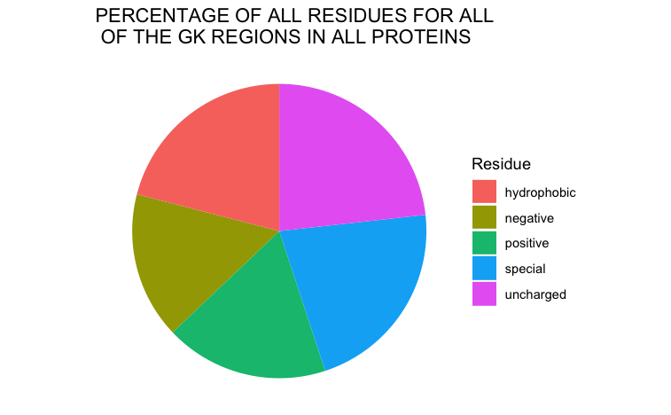

```r
pie_plot_percentage_of_all_residues(GK_analysis$cts_gk_fl_groups, "GK REGIONS")
```

## Interested residues

Lysine (Lys) –> K  
Arginine (Arg) –> R  
Aspartic acid (Asp) –> D  
Glutamic acid (Glu) –> E  
Serine (Ser) –> S  
Proline (Pro) –> P  
PERCENTAGE OF INTERESTED RESIDUES FOR ALL OF THE GK REGIONS IN ALL PROTEINS

```r
GK_analysis_interested_aa = analyse_interested_gate_keeper_regions(GK_analysis)
```

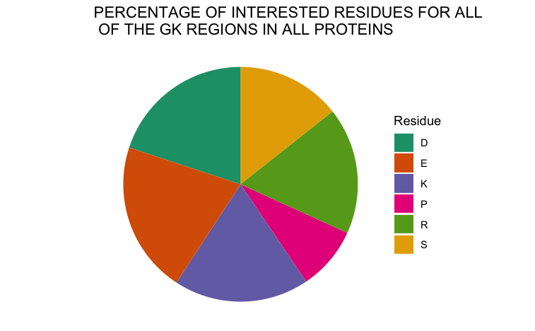

```r
pie_plot_percentage_of_interested_residues(GK_analysis_interested_aa$cts_interest_gk, "GK REGIONS")
```

PERCENTAGE OF INTERESTED RESIDUES FOR ALL OF THE GK + FL REGIONS IN ALL PROTEINS

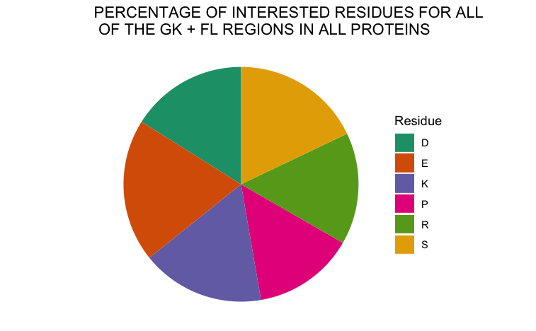

```r
pie_plot_percentage_of_interested_residues(GK_analysis_interested_aa$cts_interest_gk_fl, "GK + FL REGIONS")
```

PERCENTAGE OF INTERESTED RESIDUES FOR ALL OF THE GK SIDES

```r
GK_analysis_GK_residues = analyse_gate_keeper_residues(GK_analysis$cts_gk_side)
side_string = "GK"
```

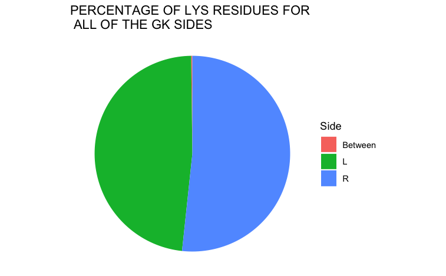

```r
pie_plot_percentage_of_specific_residue(GK_analysis_GK_residues$lys_ct, "LYS", side_string)
```

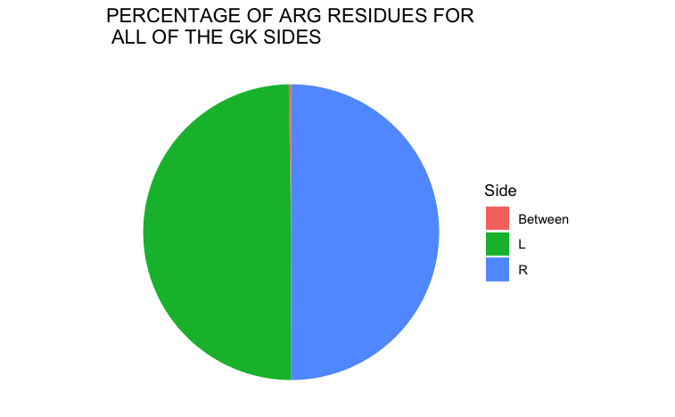

```r
pie_plot_percentage_of_specific_residue(GK_analysis_GK_residues$arg_ct, "ARG", side_string)
```

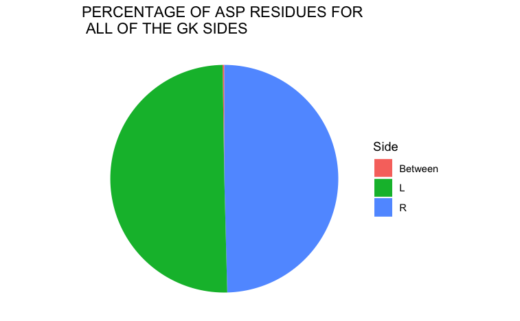

```r
pie_plot_percentage_of_specific_residue(GK_analysis_GK_residues$asp_ct, "ASP", side_string)
```

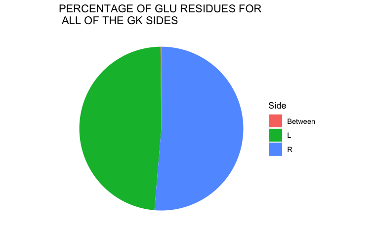

```r
pie_plot_percentage_of_specific_residue(GK_analysis_GK_residues$glu_ct, "GLU", side_string)
```

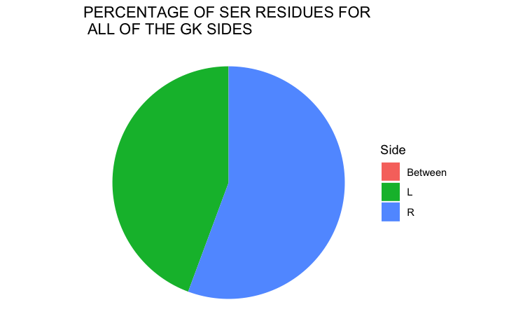

```r
pie_plot_percentage_of_specific_residue(GK_analysis_GK_residues$ser_ct, "SER", side_string)
```

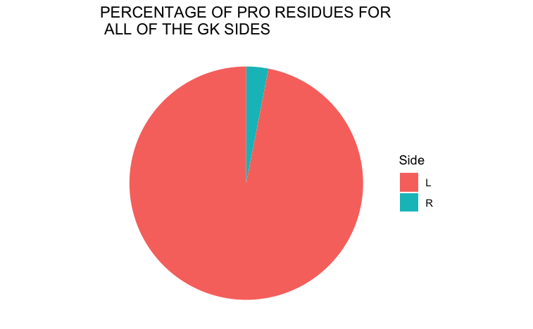

```r
pie_plot_percentage_of_specific_residue(GK_analysis_GK_residues$pro_ct, "PRO", side_string)
```

PERCENTAGE OF INTERESTED RESIDUES FOR ALL OF THE GK + FL SIDES

```r
GK_analysis_GK_and_FL_residues = analyse_gate_keeper_residues(GK_analysis$cts_gk_fl_side)
side_string = "GK + FL"
```

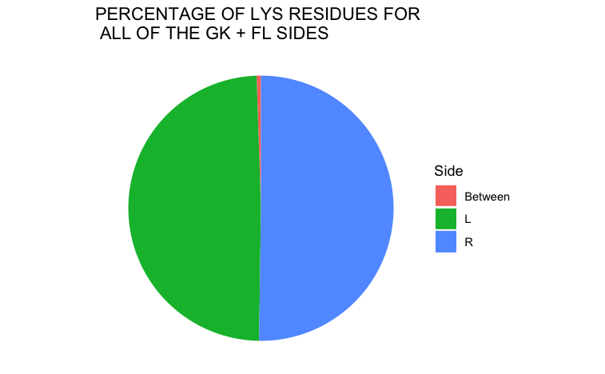

```r
pie_plot_percentage_of_specific_residue(GK_analysis_GK_and_FL_residues$lys_ct, "LYS", side_string)
```

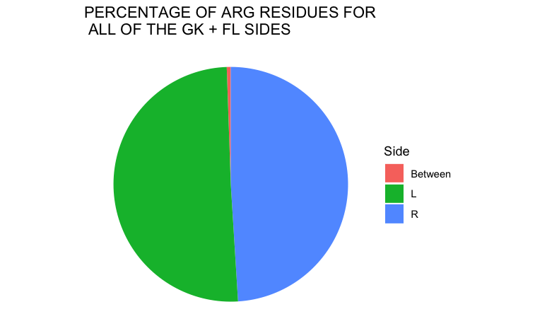

```r
pie_plot_percentage_of_specific_residue(GK_analysis_GK_and_FL_residues$arg_ct, "ARG", side_string)
```

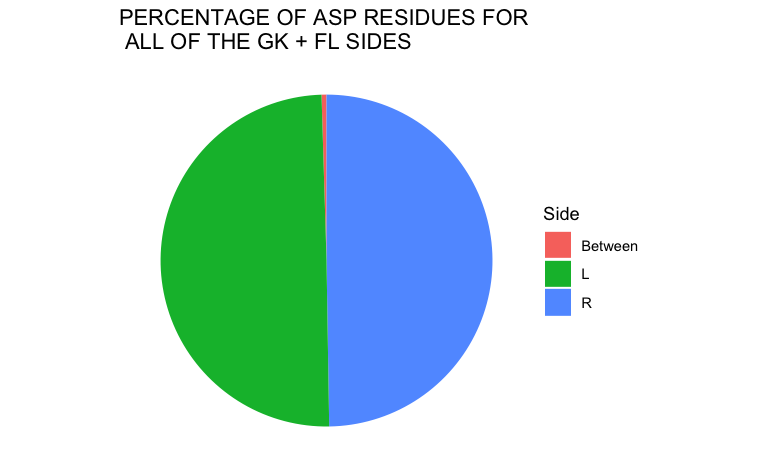

```r
pie_plot_percentage_of_specific_residue(GK_analysis_GK_and_FL_residues$asp_ct, "ASP", side_string)
```

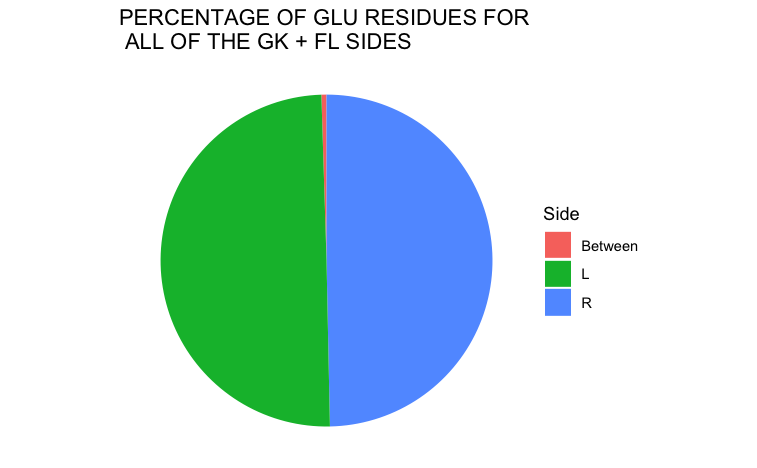

```r
pie_plot_percentage_of_specific_residue(GK_analysis_GK_and_FL_residues$glu_ct, "GLU", side_string)
```

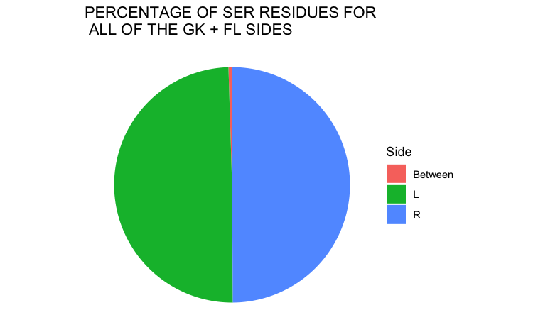

```r
pie_plot_percentage_of_specific_residue(GK_analysis_GK_and_FL_residues$ser_ct, "SER", side_string)
```

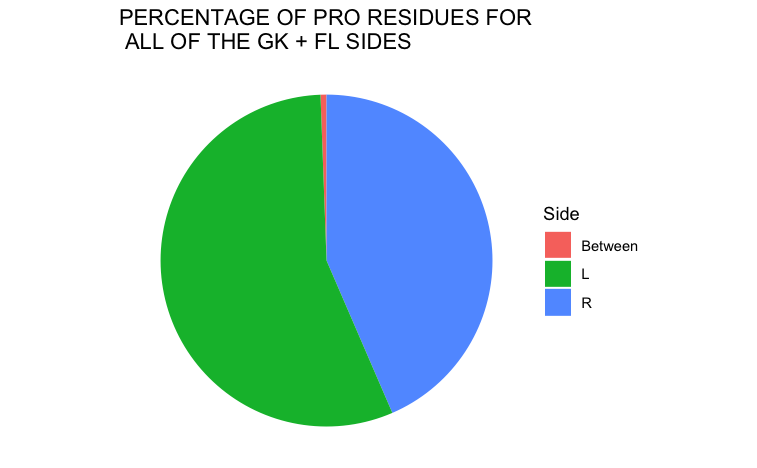

```r
pie_plot_percentage_of_specific_residue(GK_analysis_GK_and_FL_residues$pro_ct, "PRO", side_string)
```

```r
GK_analysis_GK_groupings = analyse_gate_keeper_groupings(GK_analysis$cts_gk_groups_side)
side_string = "GK"
```

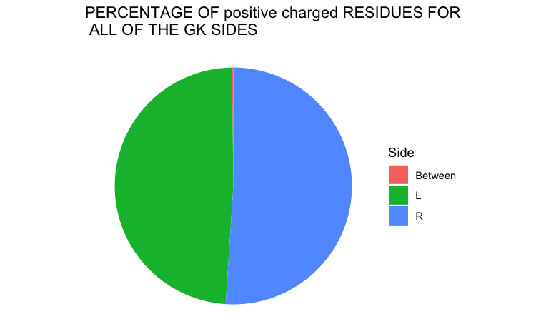

```r
pie_plot_percentage_of_specific_residue(GK_analysis_GK_groupings$positive, "positive charged", side_string)
```

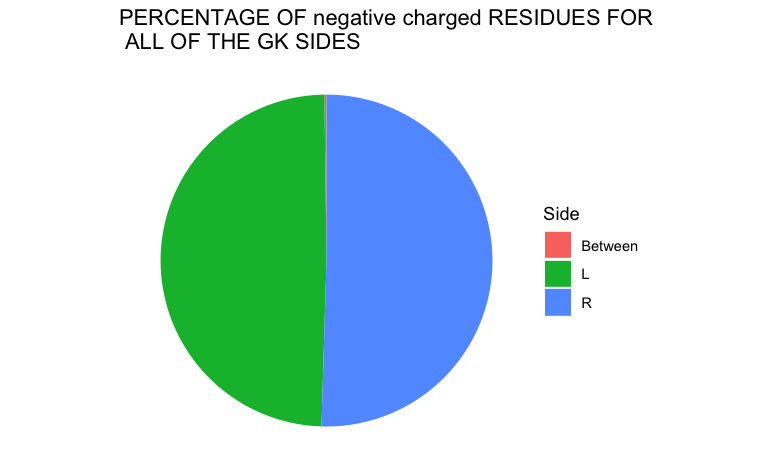

```r
pie_plot_percentage_of_specific_residue(GK_analysis_GK_groupings$negative, "negative charged", side_string)
```

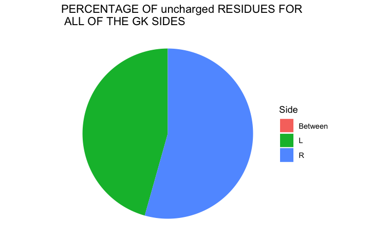

```r
pie_plot_percentage_of_specific_residue(GK_analysis_GK_groupings$uncharged, "uncharged", side_string)
```

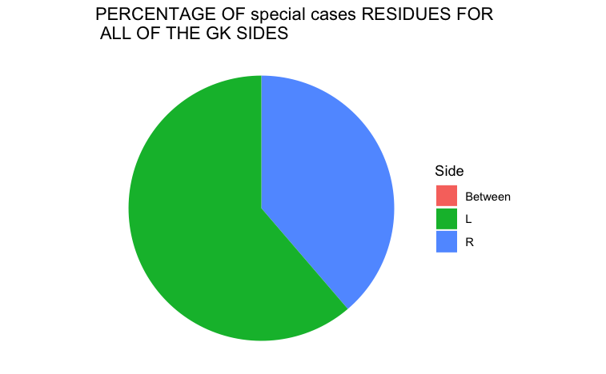

```r
pie_plot_percentage_of_specific_residue(GK_analysis_GK_groupings$special, "special cases", side_string)
```

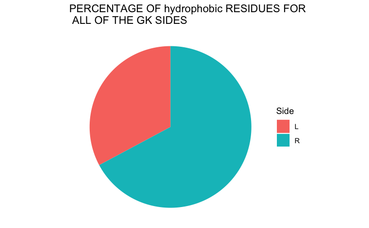

```r
pie_plot_percentage_of_specific_residue(GK_analysis_GK_groupings$hydrophobic, "hydrophobic", side_string)
```

PERCENTAGE OF INTERESTED RESIDUES FOR ALL OF THE GK + FL SIDES

```r
GK_analysis_GK_and_FL_groupings = analyse_gate_keeper_groupings(GK_analysis$cts_gk_fl_groups_side)
side_string = "GK + FL"
```

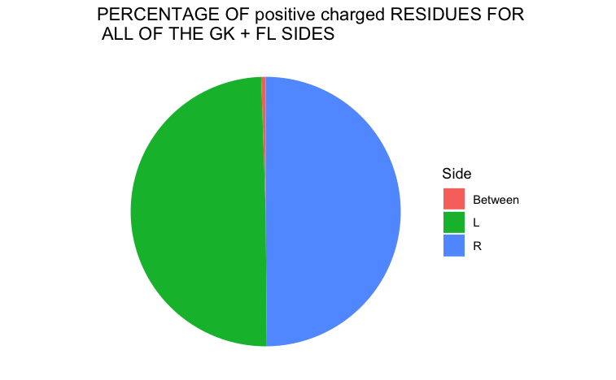

```r
pie_plot_percentage_of_specific_residue(GK_analysis_GK_and_FL_groupings$positive, "positive charged", side_string)
```

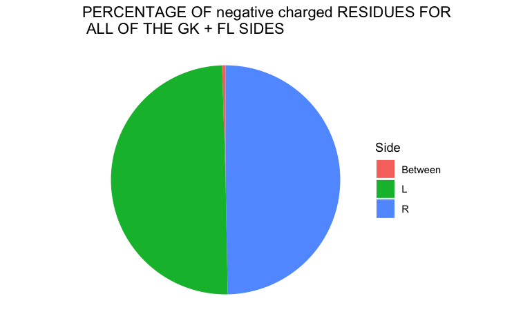

```r
pie_plot_percentage_of_specific_residue(GK_analysis_GK_and_FL_groupings$negative, "negative charged", side_string)
```

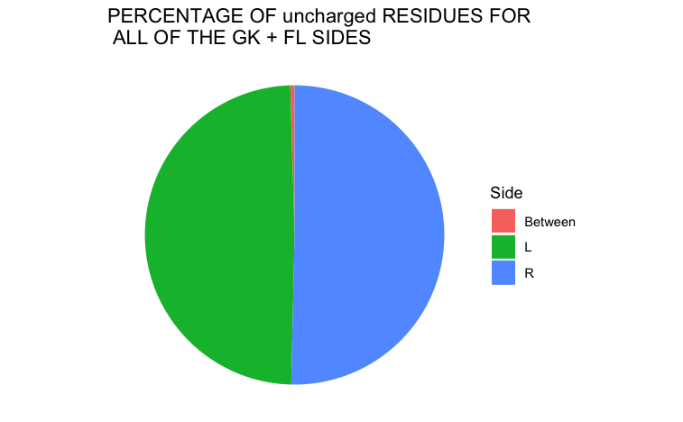

```r
pie_plot_percentage_of_specific_residue(GK_analysis_GK_and_FL_groupings$uncharged, "uncharged", side_string)
```

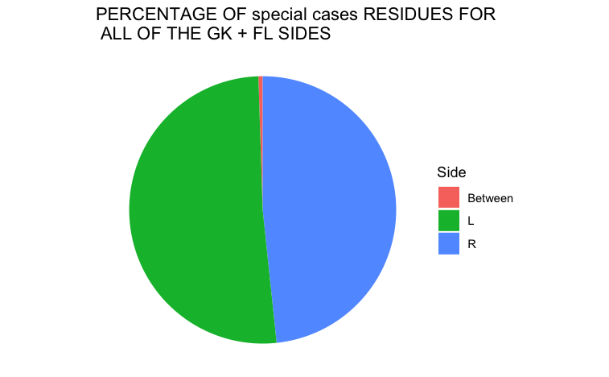

```r
pie_plot_percentage_of_specific_residue(GK_analysis_GK_and_FL_groupings$special, "special cases", side_string)
```

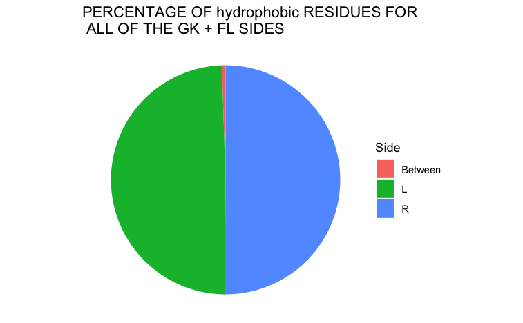

```r
pie_plot_percentage_of_specific_residue(GK_analysis_GK_and_FL_groupings$hydrophobic, "hydrophobic", side_string)
```